# Analyze A/B Test Results

- Introduction
- Part I - Probability
- Part II - A/B Test
- Part III - Regression

## Introduction

A/B tests are very commonly performed by data analysts and data scientists.

For this project, I work to understand the results of a hypothetical A/B test run by an e-commerce website. The goal is to determine whether the company should implement the new page, keep the old page, or gather more information by running the experiment longer.

## Part I - Probability

To get started, let's import our libraries.

```python
import pandas as pd
import numpy as np
import random
import matplotlib.pyplot as plt
%matplotlib inline
random.seed(42)
```

`1.` reading in the `ab_data.csv` data. And Storing it in `df` as a DataFrame.

a. Reading in the data set and showing five first lines

```python
df = pd.read_csv('ab_data.csv')
df.head()
```

|  | user_id | timestamp | group | landing_page | converted |
| --- | --- | --- | --- | --- | --- |
| 0 | 851104 | 2017-01-21 22:11:48.556739 | control | old_page | 0 |
| 1 | 804228 | 2017-01-12 08:01:45.159739 | control | old_page | 0 |
| 2 | 661590 | 2017-01-11 16:55:06.154213 | treatment | new_page | 0 |
| 3 | 853541 | 2017-01-08 18:28:03.143765 | treatment | new_page | 0 |
| 4 | 864975 | 2017-01-21 01:52:26.210827 | control | old_page | 1 |

b. Number of rows in the dataset :

```python
# number of rows in the dataset
df.shape[0]
```

```
294478
```

c. Number of unique users in the dataset :

```python
# number of unique users
df['user_id'].nunique()
```

```
290584
```

d. The proportion of users converted.

```python
# the prop of users converted is the number of converted users divided by the total number of users
prop_convert = df.query(" converted == 1")['converted'].count()/df.shape[0]
prop_convert
```

```
0.11965919355605512
```

e. The number of times the `new_page` and `treatment` don't match.

```python
# There are two cases of non match :
# first : landing page is not new_page but group is treatment group
no_match_1 = df.query(" landing_page != 'new_page' and group == 'treatment'")['user_id'].count()
# second : landing page is new_page but group is not treatment group
no_match_2 = df.query(" landing_page == 'new_page' and group != 'treatment'")['user_id'].count()
# np_match is the sum of the two cases
no_match = no_match_1 + no_match_2
no_match
```

```
3893
```

f. Checking if the rows have missing values

```python
df.isnull().sum() # no messing values
```

```
user_id         0
timestamp       0
group           0
landing_page    0
converted       0
dtype: int64
```

`2.` For the rows where **treatment** does not match with **new_page** or **control** does not match with **old_page**, we cannot be sure if this row truly received the new or old page.

a. Creating a new dataset that meets the specifications and storing the new dataframe in **df2**.

```python
# df_treatment is a dataframe where new_page and treatment match
df_treatment = df.query("landing_page == 'new_page' and group == 'treatment' ")
```

```python
# df_control is a dataframe wherer old_page and control match
df_control = df.query("landing_page == 'old_page' and group == 'control' ")
```

```python
# merging the two dataframes
frames = [df_control, df_treatment]
df2 = pd.concat(frames)
```

```python
# Double Check all of the correct rows were removed - this should be 0
df2[((df2['group'] == 'treatment') == (df2['landing_page'] == 'new_page')) == False].shape[0]
```

```
0
```

`3.` Checking the new dataframe df2 characteristics.

a. Number of unique **user_id**s in **df2**?

```python
# unique user_ids in df2
df2['user_id'].nunique()
```

```
290584
```

b. Checking repeated **user_id** in **df2**.

```python
# user_id : 773192 is repeated
df2[df2.duplicated('user_id')]
```

|  | user_id | timestamp | group | landing_page | converted |
| --- | --- | --- | --- | --- | --- |
| 2893 | 773192 | 2017-01-14 02:55:59.590927 | treatment | new_page | 0 |

c. Checking out the repeated **user_id**?

```python
# check out the repeated user_id
df2.query("user_id == '773192' ")
```

|  | user_id | timestamp | group | landing_page | converted |
| --- | --- | --- | --- | --- | --- |
| 1899 | 773192 | 2017-01-09 05:37:58.781806 | treatment | new_page | 0 |
| 2893 | 773192 | 2017-01-14 02:55:59.590927 | treatment | new_page | 0 |

d. Removing **one** of the rows with a duplicate **user_id**

```python
# removing one of the repeated user_id
df2 = df2.drop([1899])
```

`4.` Other Probabilities based on the df2 dataframe

a. The probability of an individual converting regardless of the page they receive

```python
# the probability of coverting is the number of observations with converting divided by the total number of observations
df2_convert = df2.query(" converted == 1")
p_convert = df2.query(" converted == 1")['user_id'].count()/df2.shape[0]

p_convert
```

```
0.11959708724499628
```

b. Given that an individual was in the `control` group, what is the probability they converted?

```python
# let's create a subset of data corresponding to the control group
df2_control = df2.query(" group == 'control'")
```

```python
# Calculate the probability of convert within the control group
p_control_convert = df2_control.query(" converted == 1")['user_id'].count()/df2_control.shape[0]

p_control_convert
```

```
0.1203863045004612
```

c. Given that an individual was in the `treatment` group, what is the probability they converted?

```python
# let's create a subset of data corresponding to the treatment group
df2_treatment = df2.query(" group == 'treatment'")
```

```python
# Calculate the probability of convert within the treatment group
p_treatment_convert = df2_treatment.query(" converted == 1")['user_id'].count()/df2_treatment.shape[0]

p_treatment_convert
```

```
0.11880806551510564
```

d. The probability that an individual received the new page

```python
# the probability of receiving the new page
p_newpage = df2.query(" landing_page == 'new_page'")['user_id'].count()/df2.shape[0]

p_newpage
```

```
0.50006194422266881
```

**In this sample, based on the results above the average convert within the treatment group (0.1188) is less than the average convert within the control group (0.1203). However we don't have the evidence that this result is statistacally significant and not due only to chance. We should go further with the analysis using hypothesis tests to make conclusion about whether or not the old page leads to more conversion**

## Part II - A/B Test

Because there is a time stamp associated with each user event, it is theoretically possible that a hypothesis test, similar to this one, could be run continuously in real time.

In this hypothetical situation, the hard questions become when to stop the test and how to reach a decision: As soon as one page is considered significantly better than the other? Once a certain page is better than another for a certain period of time? How long must the experiment be run before considering the test inconclusive? How much evidence is sufficient?

These are the difficult questions associated with A/B tests in general.

For the hypothetical A/B test considered in this section, the null and alternative hypotheses are as follows:

**H0** : **$p_{new}$** - **$p_{old}$** <= 0  
**H1** : **$p_{new}$** - **$p_{old}$** > 0

Or, verbally:

H0 : The likelihood of conversion for a user receiving the new page is less than or equal to the likelihood of conversion for a user receiving the old page.  
H1 : The likelihood of conversion for a user receiving the new page is greater than the likelihood of conversion for a user receiving the old page.

`2.` For the next section, assume the null hypothesis. That is, assume pnew and pold both have "true" success rates equal to the converted success rate regardless of page.

Use a sample size for each page equal to the ones in **ab_data.csv**.

Perform the sampling distribution for the difference in **converted** between the two pages over 10,000 iterations of calculating an estimate from the null.

Use the cells below to provide the necessary parts of this simulation. If this doesn't make complete sense right now, don't worry - you are going to work through the problems below to complete this problem. You can use **Quiz 5** in the classroom to make sure you are on the right track.

a. What is the **conversion rate** for $p_{new}$ under the null ?

```python
# conversion rate for  𝑝𝑛𝑒𝑤  under the null
p_new_H0 = df2['converted'].mean()
p_new_H0
```

```
0.11959708724499628
```

b. What is the **conversion rate** for $p_{old}$ under the null?

```python
# conversion rate for  𝑝𝑜𝑙𝑑  under the null
p_old_H0 = df2['converted'].mean()
p_old_H0
```

```
0.11959708724499628
```

c. What is $n_{new}$, the number of individuals in the treatment group?

```python
# number of individuals in the treatment group
n_new = df2.query(" group == 'treatment'").shape[0]
n_new
```

```
145310
```

d. What is $n_{old}$, the number of individuals in the control group?

```python
# number of individuals in the control group
n_old = df2.query(" group == 'control'").shape[0]
n_old
```

```
145274
```

Next, performing the sampling distribution for the difference in converted between the two pages over 10,000 iterations of calculating an estimate from the null.

e. Simulation of $n_{new}$ transactions with a conversion rate of $p_{new}$ under the null. Storing these $n_{new}$ 1's and 0's in **new_page_converted**.

```python
new_page_converted = np.random.binomial(1, p_new_H0, n_new )
p_new = new_page_converted.mean()
```

f. Simulation of $n_{old}$ transactions with a conversion rate of $p_{old}$ under the null. Storing these $n_{old}$ 1's and 0's in **old_page_converted**.

```python
old_page_converted = np.random.binomial(1, p_old_H0, n_old )
p_old = old_page_converted.mean()
```

g. What is $p_{new}$ - $p_{old}$ for our simulated values from part (e) and (f).

```python
diff = p_new - p_old
diff
```

```
-0.0011998828064638811
```

h. Creating 10,000 $p_{new}$ - $p_{old}$ values using the same simulation process I used in parts (a) through (g) above. Storing all 10,000 values in a NumPy array called **p_diffs**.

```python
p_diffs = []
for _ in range(10000):
    new_page_converted = np.random.binomial(1, p_new_H0, n_new )
    old_page_converted = np.random.binomial(1, p_old_H0, n_old )
    p_new = new_page_converted.mean()
    p_old = old_page_converted.mean()
    p_diffs.append( p_new - p_old )
```

i. This boils down to a computation of the "spread" of the data, assuming that the probability of converting a given user is the same whether they see the treatment page or the control page.

```python
# lets transform p_diffs to a NumPy array
p_diffs = np.array(p_diffs)
```

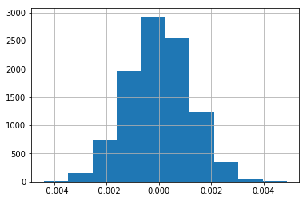

```python
# Plotting the histogram
plt.hist(p_diffs);
plt.grid()
```

j. What proportion of the **p_diffs** are greater than the actual difference observed in **ab_data.csv**?

```python
# camputing the observed difference in ab_data.csv
obs_diff = p_treatment_convert - p_control_convert
```

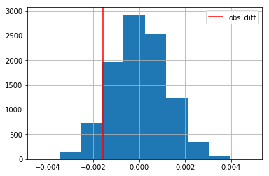

```python
# plotting both : histogram of p_diffs and the observed difference in ab_data.csv
plt.hist(p_diffs)
plt.grid()
plt.axvline(x = obs_diff, color='r', label='obs_diff')
plt.legend();
```

```python
# calculating the p_value
p_value = (p_diffs > obs_diff).mean()
p_value
```

```
0.90620000000000001
```

## Built-In Stats Model

I could also use a built-in to achieve similar results. Though using the built-in might be easier to code, the above portions are a walkthrough of the ideas that are critical to correctly thinking about statistical significance.

Let's calculate the number of conversions for each page, as well as the number of individuals who received each page. `n_old` and `n_new` refer the the number of rows associated with the old page and new pages, respectively.

```python
import statsmodels.api as sm

convert_old = df2.query(" group == 'control'")['converted'].sum()
convert_new = df2.query(" group == 'treatment'")['converted'].sum()
n_old = df2.query(" group == 'control'").shape[0]
n_new = df2.query(" group == 'treatment'").shape[0]
convert_old, convert_new, n_old, n_new
```

```
(17489, 17264, 145274, 145310)
```

m. Let's use `stats.proportions_ztest` to compute the test statistic and p-value.

```python
count = np.array([convert_old, convert_new])
nobs = np.array([n_old, n_new])
stat, pval = sm.stats.proportions_ztest(count, nobs, alternative='smaller')
stat, pval
```

```
(1.3109241984234394, 0.90505831275902449)
```

**The z-score is the number of standard deviations from the mean a data point. Since the z-score in this case of 1.31 is within the range implied by the critical value of 1.96, we fail to reject the null hypothesis.**

**On the other hand, since the p_value of 0.90 (approximately the same value as calculated before) is larger than the type I error rate (5%), we fail to reject the null hypothesis. We conclude that the two methods leads to the same conclusion.**

## Part III - A regression approach

`1.` This final part demonstrates that the result acheived in the previous A/B test can also be acheived by performing regression.

In this section, I utilize **statsmodels** to fit a logistic regression model to see if there is a significant difference in conversion depending on which page a customer receives.

First, I add a column for the intercept, called intercept. Then I create a dummy variable column for which page each user received. That column is called ab_page. It is 1 when a user receives treatment and 0 if the user receives control.

```python
# Adding an intercept column to the dataframe
df2['intercept'] = 1
```

```python
# 'landing_page' dummy variables
df_group_dummy = pd.get_dummies(df['group'])
```

```python
# merging dataframes  : df2 and df_page_dummy
df2 = df2.join(df_group_dummy)
```

```python
# renaming treatment column to ab_page
df2 = df2.rename(columns={'treatment': 'ab_page'})
```

```python
# dropping control column
df2 = df2.drop('control' , axis = 1)
```

```python
df2.head()
```

|  | user_id | timestamp | group | landing_page | converted | intercept | ab_page |
| --- | --- | --- | --- | --- | --- | --- | --- |
| 0 | 851104 | 2017-01-21 22:11:48.556739 | control | old_page | 0 | 1 | 0 |
| 1 | 804228 | 2017-01-12 08:01:45.159739 | control | old_page | 0 | 1 | 0 |
| 4 | 864975 | 2017-01-21 01:52:26.210827 | control | old_page | 1 | 1 | 0 |
| 5 | 936923 | 2017-01-10 15:20:49.083499 | control | old_page | 0 | 1 | 0 |
| 7 | 719014 | 2017-01-17 01:48:29.539573 | control | old_page | 0 | 1 | 0 |

c. The following line instantiates the regression model using **statsmodels**

```python
# define the logistic regression model
logit_mod = sm.Logit(df2['converted'] , df2[['intercept' , 'ab_page']])
```

fitting the model using the intercept and ab_page columns. The model predicts whether or not a user converts.

```python
result = logit_mod.fit()
```

```
Optimization terminated successfully.
         Current function value: 0.366118
         Iterations 6
```

d. Providing the summary of the model below

```python
# model summary
result.summary()
```

Logit Regression Results

| Dep. Variable: | converted | No. Observations: | 290584 |
| --- | --- | --- | --- |
| Model: | Logit | Df Residuals: | 290582 |
| Method: | MLE | Df Model: | 1 |
| Date: | Tue, 25 Jun 2019 | Pseudo R-squ.: | 8.077e-06 |
| Time: | 12:01:07 | Log-Likelihood: | -1.0639e+05 |
| converged: | True | LL-Null: | -1.0639e+05 |
|  |  | LLR p-value: | 0.1899 |

|  | coef | std err | z | P>\|z\| | [0.025 | 0.975] |
| --- | --- | --- | --- | --- | --- | --- |
| intercept | -1.9888 | 0.008 | -246.669 | 0.000 | -2.005 | -1.973 |
| ab_page | -0.0150 | 0.011 | -1.311 | 0.190 | -0.037 | 0.007 |

e. What is the p-value associated with **ab_page**? Why does it differ from the value you found in **Part II**?

**The p-value associated with ab_page gived by the logistic regression model is 0.19. The p-value of part II calculated from the built-in ztest method was about 0.90.**

**In part 3, The null hypothesis associated with our logistic regression model is that there is no relationship between the response variable and explanatory variables. This means there is no relationship between which page is displayed and the conversion rate. The alternative hypothes is that there is a relationship.**

**However, The null hypothesis from part 2 is : the likelihood of conversion for a user receiving the new page is less than or equal to the likelihood of conversion for a user receiving the old page. The alternative hypothesis is that the likelihood of conversion for a user receiving the new page is greater than the likelihood of conversion for a user receiving the old page.**

**There is a large difference in the p-values comparing the results of part 2 and part 3 We can explain this difference by some factors like that part 2 hypothesized one of the pages would lead to more conversions than the other. This is different from the hypotheses of part 3, which merely predicted a difference of some sort.**

## Additional Factors

Including additional factors may make the model more predictive, yielding greater understanding. It may also result in business insights that would not have been evident in this simpler anlysis. For example, it would be possible to have different versions of the website for different locations. It is likely that people from different countries might have different tastes in website layout.

Possible disadvantages of additional factors include increased risk of human error, especially misinterpretation, as well as possibly obscuring the message the data is really trying to tell (decreasing the so-called signal-to-noise ratio).

Next, I add an additional factor for the country in which a user lives. I read in an additional file called countries.csv and merge it with the users dataframe.

For future reference, [Here](https://pandas.pydata.org/pandas-docs/stable/generated/pandas.DataFrame.join.html) are the docs for joining tables.

Finally, I generate dummy variables for these country columns.

```python
# reading countries data frame
df_countries = pd.read_csv('countries.csv')
df_countries.head()
```

|  | user_id | country |
| --- | --- | --- |
| 0 | 834778 | UK |
| 1 | 928468 | US |
| 2 | 822059 | UK |
| 3 | 711597 | UK |
| 4 | 710616 | UK |

```python
# merge dataframes on 'user_id' using inner join
df3 = df_countries.set_index('user_id').join(df2.set_index('user_id') , on = 'user_id' , how = 'inner' )
```

```python
df3.head()
```

| user_id | country | timestamp | group | landing_page | converted | intercept | ab_page |
| --- | --- | --- | --- | --- | --- | --- | --- |
| 834778 | UK | 2017-01-14 23:08:43.304998 | control | old_page | 0 | 1 | 0 |
| 928468 | US | 2017-01-23 14:44:16.387854 | treatment | new_page | 0 | 1 | 1 |
| 822059 | UK | 2017-01-16 14:04:14.719771 | treatment | new_page | 1 | 1 | 1 |
| 711597 | UK | 2017-01-22 03:14:24.763511 | control | old_page | 0 | 1 | 0 |
| 710616 | UK | 2017-01-16 13:14:44.000513 | treatment | new_page | 0 | 1 | 1 |

```python
# setting dumy variables for country
df3[['CA', 'UK' , 'US']] = pd.get_dummies(df3['country'])
df3.head()
```

| user_id | country | timestamp | group | landing_page | converted | intercept | ab_page | CA | UK | US |
| --- | --- | --- | --- | --- | --- | --- | --- | --- | --- | --- |
| 834778 | UK | 2017-01-14 23:08:43.304998 | control | old_page | 0 | 1 | 0 | 0 | 1 | 0 |
| 928468 | US | 2017-01-23 14:44:16.387854 | treatment | new_page | 0 | 1 | 1 | 0 | 0 | 1 |
| 822059 | UK | 2017-01-16 14:04:14.719771 | treatment | new_page | 1 | 1 | 1 | 0 | 1 | 0 |
| 711597 | UK | 2017-01-22 03:14:24.763511 | control | old_page | 0 | 1 | 0 | 0 | 1 | 0 |
| 710616 | UK | 2017-01-16 13:14:44.000513 | treatment | new_page | 0 | 1 | 1 | 0 | 1 | 0 |

```python
# Fitting logistic regression model (US is the baseline)
logmod = sm.Logit(df3['converted'] , df3[['intercept' , 'ab_page' , 'CA' , 'UK']])
result = logmod.fit()
result.summary()
```

```
Optimization terminated successfully.
         Current function value: 0.366113
         Iterations 6
```

Logit Regression Results

| Dep. Variable: | converted | No. Observations: | 290584 |
| --- | --- | --- | --- |
| Model: | Logit | Df Residuals: | 290580 |
| Method: | MLE | Df Model: | 3 |
| Date: | Tue, 25 Jun 2019 | Pseudo R-squ.: | 2.323e-05 |
| Time: | 12:07:47 | Log-Likelihood: | -1.0639e+05 |
| converged: | True | LL-Null: | -1.0639e+05 |
|  |  | LLR p-value: | 0.1760 |

|  | coef | std err | z | P>\|z\| | [0.025 | 0.975] |
| --- | --- | --- | --- | --- | --- | --- |
| intercept | -1.9893 | 0.009 | -223.763 | 0.000 | -2.007 | -1.972 |
| ab_page | -0.0149 | 0.011 | -1.307 | 0.191 | -0.037 | 0.007 |
| CA | -0.0408 | 0.027 | -1.516 | 0.130 | -0.093 | 0.012 |
| UK | 0.0099 | 0.013 | 0.743 | 0.457 | -0.016 | 0.036 |

It is necessary to exponentiate these coefficients since this is logistic regression.

```python
# Calculate exponential of coefficients
CA_coef = np.exp(-0.0408)
UK_coef = np.exp(0.0099)
print (CA_coef)
print (UK_coef)
```

```
0.960021114972
1.00994916712
```

```python
# let's calculate the reciprocal for CA_coef
1/CA_coef
```

```
1.0416437559600236
```

**The interpretation of the foregoing variables is counterintuitive. In this case, United States is the baseline since it was the one out of three variables that wasn't included in the regression. We would say that CA users are 0.96 times as likely (or 4% less likely) to convert as US users. Similarly, we would say that UK users are 1.01 times as likely (or 1% more likely) to convert as US users.**

**The effect is not statistically significant, given the fairly large P-values. Even if it were, it is not clear that such a small difference between the different countries would be practically significant.**

### Interaction Terms

h. Though I have now looked at the individual factors of country and page on conversion, I would now like to look at an interaction between page and country to see if there significant effects on conversion.

Let's Create the necessary additional columns, and fit the new model.

```python
#Columns corresponding to interaction between page and countries
df3['CA_int'] = df3['ab_page'] * df3['CA']
df3['UK_int'] = df3['ab_page'] * df3['UK']
df3['US_int'] = df3['ab_page'] * df3['US']
df3.head()
```

| user_id | country | timestamp | group | landing_page | converted | intercept | ab_page | CA | UK | US | CA_int | UK_int | US_int |
| --- | --- | --- | --- | --- | --- | --- | --- | --- | --- | --- | --- | --- | --- |
| 834778 | UK | 2017-01-14 23:08:43.304998 | control | old_page | 0 | 1 | 0 | 0 | 1 | 0 | 0 | 0 | 0 |
| 928468 | US | 2017-01-23 14:44:16.387854 | treatment | new_page | 0 | 1 | 1 | 0 | 0 | 1 | 0 | 0 | 1 |
| 822059 | UK | 2017-01-16 14:04:14.719771 | treatment | new_page | 1 | 1 | 1 | 0 | 1 | 0 | 0 | 1 | 0 |
| 711597 | UK | 2017-01-22 03:14:24.763511 | control | old_page | 0 | 1 | 0 | 0 | 1 | 0 | 0 | 0 | 0 |
| 710616 | UK | 2017-01-16 13:14:44.000513 | treatment | new_page | 0 | 1 | 1 | 0 | 1 | 0 | 0 | 1 | 0 |

```python
# Fitting logistic regression model
logmod = sm.Logit(df3['converted'] , df3[['intercept' , 'ab_page' , 'CA' , 'CA_int' , 'UK' , 'UK_int']])
result = logmod.fit()
result.summary()
```

```
Optimization terminated successfully.
         Current function value: 0.366109
         Iterations 6
```

Logit Regression Results

| Dep. Variable: | converted | No. Observations: | 290584 |
| --- | --- | --- | --- |
| Model: | Logit | Df Residuals: | 290578 |
| Method: | MLE | Df Model: | 5 |
| Date: | Tue, 25 Jun 2019 | Pseudo R-squ.: | 3.482e-05 |
| Time: | 12:13:59 | Log-Likelihood: | -1.0639e+05 |
| converged: | True | LL-Null: | -1.0639e+05 |
|  |  | LLR p-value: | 0.1920 |

|  | coef | std err | z | P>\|z\| | [0.025 | 0.975] |
| --- | --- | --- | --- | --- | --- | --- |
| intercept | -1.9865 | 0.010 | -206.344 | 0.000 | -2.005 | -1.968 |
| ab_page | -0.0206 | 0.014 | -1.505 | 0.132 | -0.047 | 0.006 |
| CA | -0.0175 | 0.038 | -0.465 | 0.642 | -0.091 | 0.056 |
| CA_int | -0.0469 | 0.054 | -0.872 | 0.383 | -0.152 | 0.059 |
| UK | -0.0057 | 0.019 | -0.306 | 0.760 | -0.043 | 0.031 |
| UK_int | 0.0314 | 0.027 | 1.181 | 0.238 | -0.021 | 0.084 |

**Giving the high p-values associated with this logistic regression for the case with the interaction terms, we can fairly conclude that the interaction terms are not especially predictive of results.**

## Conclusion

Throughout this project, we run two different aproches (a/b tests and logistic regresion) to study the results of implementation of a new page for an ecommerce website. Given the results of both approches the conclusion of this study has to be that the the new page does not have a statistically significant impact on new user conversions. This mean the company should stick with the old web page.